# Homework 10

```r
library(RLT)
library(knitr)
```

Solutions for Questions 1 and 2 will be available after Monday, November 2, 2026. No solution will be provided for Question 3.

Use the RLT package for Questions 1 and 2: `RLT` in R or `rlt` in Python. The node-size parameter is `nmin` in R and `min_samples_leaf` in Python; both stop splitting a node when it contains at most that many observations. The candidate-predictor parameter is `mtry` in both languages. Use ordinary random forests, with reinforcement turned off.

## Question 1: Bias-variance trade-off simulation

Two important tuning parameters of random forests are node size and `mtry`. We have performed some preliminary analysis in class. The goal of this question is to perform a larger simulation study for these two tuning parameters.

Consider a regression model with five jointly normally distributed predictors. Each predictor has mean 0 and variance 1, and the correlation between any two different predictors is 0.3. The response is

$$Y=X_1+X_3+X_5+\varepsilon,
\qquad \varepsilon\sim N(0,1),$$

where the noise is independent of the predictors. Thus the true regression function is $f(\mathbf{x})=x_1+x_3+x_5$.

1. Set up a simulation study with 100 repetitions. Generate 200 test predictor vectors once and keep them fixed. In each repetition, generate 200 new training observations and use the same training data for all tuning settings. Fit 500-tree forests, drawing 200 observations with replacement for each tree. Make the following two comparisons:
   - Fix `mtry` at 3 and vary node size over $1,5,10,20,30$.
   - Fix node size at 10 and vary `mtry` over $1,2,3,4,5$.

   Leave all other fitting parameters at their defaults. Record the predictions at each test point across repetitions. For each setting, estimate the squared bias and variance at each test point, then average them over the 200 test points. Compare predictions with $f(\mathbf{x})$ when estimating bias. Produce two figures, one for each tuning parameter, showing the averaged squared bias and variance. Set a random seed and report it.

```r
set.seed(10102)
p <- 5; n_train <- 200; n_test <- 200; reps <- 100
R <- chol(0.7 * diag(p) + 0.3)
make_x <- function(n) matrix(rnorm(n * p), n, p) %*% R
f_fun <- function(x) x[, 1] + x[, 3] + x[, 5]
x_test <- make_x(n_test)
f_test <- f_fun(x_test)

settings <- unique(rbind(
  data.frame(nmin = c(1, 5, 10, 20, 30), mtry = 3),
  data.frame(nmin = 10, mtry = 1:5)
))

run_sim <- function(resample_prob) {
  preds <- array(NA_real_, dim = c(reps, n_test, nrow(settings)))
  for (r in 1:reps) {
    x <- make_x(n_train)
    y <- f_fun(x) + rnorm(n_train)
    for (s in seq_len(nrow(settings))) {
   invisible(capture.output(suppressMessages(
      fit <- RLT(x, y, model = "regression", ntrees = 500,
                 mtry = settings$mtry[s], nmin = settings$nmin[s],
                 resample.prob = resample_prob, replacement = TRUE,
                 reinforcement = FALSE, importance = FALSE)
   )))
      preds[r, , s] <- predict(fit, x_test)$Prediction
    }
  }
  out <- settings
  out$bias2 <- NA_real_
  out$variance <- NA_real_
  for (s in seq_len(nrow(settings))) {
    m <- colMeans(preds[, , s])
    out$bias2[s] <- mean((m - f_test)^2)
    out$variance[s] <- mean(apply(preds[, , s], 2, var))
  }
  out
}
res1 <- run_sim(1)
knitr::kable(res1, digits = 4, row.names = FALSE)
```

| nmin | mtry | bias2 | variance |
| --- | --- | --- | --- |
| 1 | 3 | 0.3072 | 0.1122 |
| 5 | 3 | 0.3125 | 0.1002 |
| 10 | 3 | 0.3498 | 0.0810 |
| 20 | 3 | 0.4664 | 0.0646 |
| 30 | 3 | 0.5953 | 0.0565 |
| 10 | 1 | 0.9695 | 0.0427 |
| 10 | 2 | 0.4737 | 0.0629 |
| 10 | 4 | 0.3023 | 0.0988 |
| 10 | 5 | 0.2765 | 0.1115 |

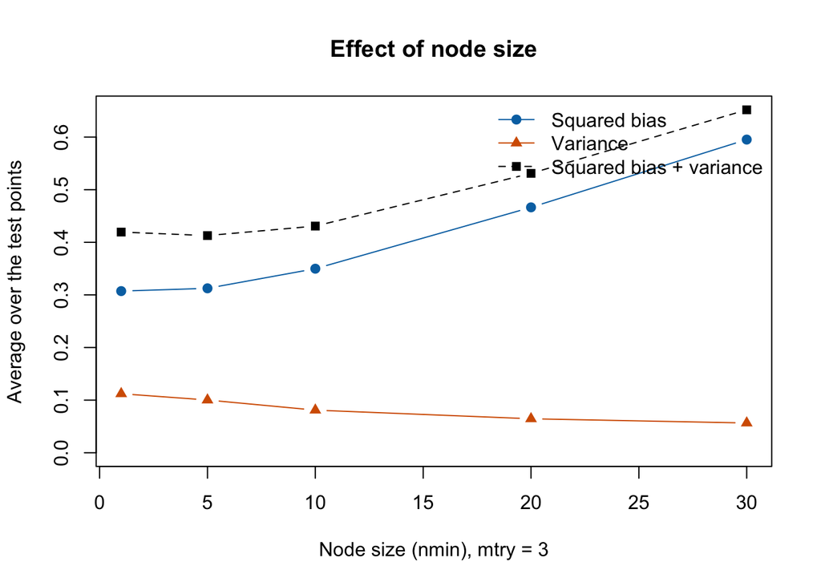

```r
plot_bv <- function(d, xvar, xlab, title) {
  yr <- range(0, d$bias2, d$variance, d$bias2 + d$variance)
  plot(d[[xvar]], d$bias2, type = "b", pch = 19, col = "#0072B2", ylim = yr,
       xlab = xlab, ylab = "Average over the test points", main = title)
  lines(d[[xvar]], d$variance, type = "b", pch = 17, col = "#D55E00")
  lines(d[[xvar]], d$bias2 + d$variance, type = "b", pch = 15, lty = 2)
  legend("topright", legend = c("Squared bias", "Variance", "Squared bias + variance"),
         col = c("#0072B2", "#D55E00", "black"), pch = c(19, 17, 15),
         lty = c(1, 1, 2), bty = "n")
}
a <- res1[res1$mtry == 3, ]
a <- a[order(a$nmin), ]
plot_bv(a, "nmin", "Node size (nmin), mtry = 3", "Effect of node size")
```

I used seed 10102. The predictors are generated as jointly normal with mean 0, variance 1, and correlation 0.3. The 200 test points are generated once and kept fixed. In each of 100 repetitions, a new training set of 200 observations is generated, and the same data are used for all tuning settings. Each forest has 500 trees, and each tree draws 200 observations with replacement. All other RLT settings are left at their defaults (the default split rule is `split.gen = "random"`); variable importance is switched off, since it does not affect the predictions. Squared bias at a test point is the squared difference between the average prediction over the 100 repetitions and the true f(x), and variance is the sample variance of the 100 predictions at that point. Both are averaged over the 200 test points.

2. Discuss your results in terms of the bias-variance trade-off:
   - How does a large node size, such as 30, affect the fit in this example?
   - What are the benefits and drawbacks of using a large `mtry` value?
   - If each tree instead sampled 100 observations with replacement, would you expect the preferred node size to shift toward smaller or larger values? Explain your reasoning. You may use an additional simulation to help, but a particular pattern is not guaranteed.

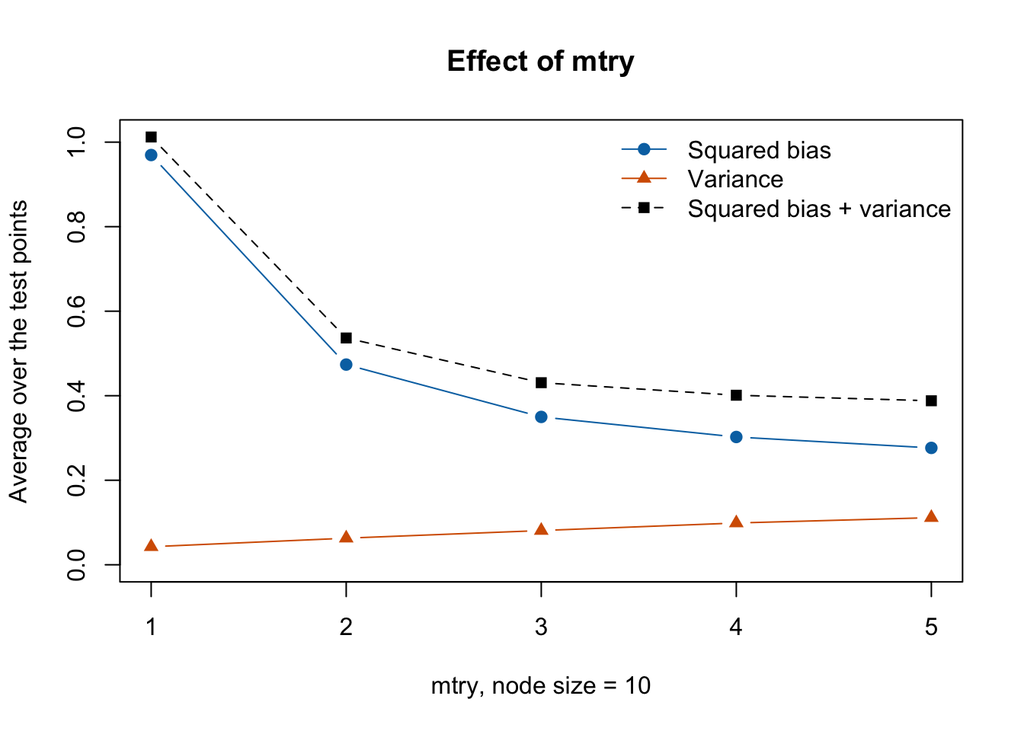

```r
b <- res1[res1$nmin == 10, ]
b <- b[order(b$mtry), ]
plot_bv(b, "mtry", "mtry, node size = 10", "Effect of mtry")
```

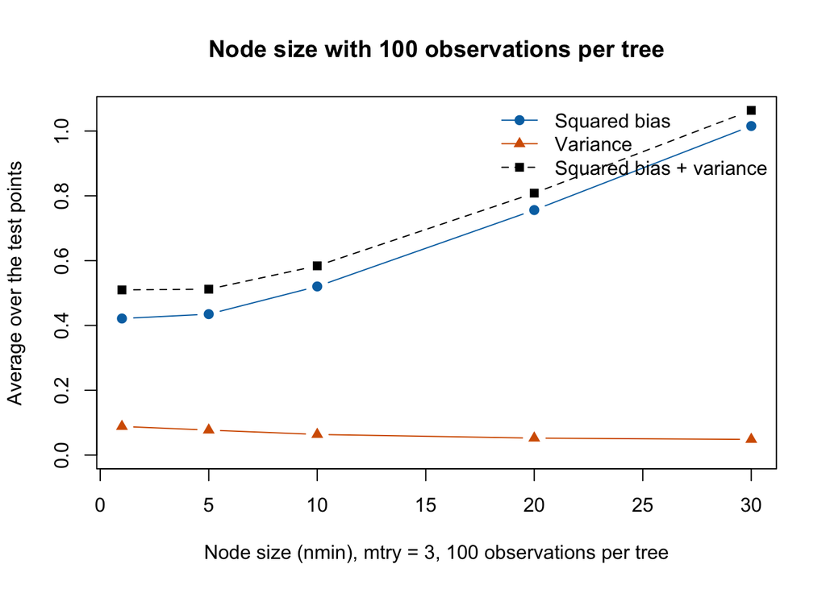

```r
res_half <- run_sim(0.5)
a2 <- res_half[res_half$mtry == 3, ]
a2 <- a2[order(a2$nmin), ]
plot_bv(a2, "nmin", "Node size (nmin), mtry = 3, 100 observations per tree",
        "Node size with 100 observations per tree")
```

```r
knitr::kable(a2, digits = 4, row.names = FALSE)
```

| nmin | mtry | bias2 | variance |
| --- | --- | --- | --- |
| 1 | 3 | 0.4214 | 0.0883 |
| 5 | 3 | 0.4349 | 0.0770 |
| 10 | 3 | 0.5204 | 0.0636 |
| 20 | 3 | 0.7561 | 0.0523 |
| 30 | 3 | 1.0154 | 0.0483 |

As the node size grows from 1 to 30, the average squared bias rises from 0.307 to 0.595, while the variance falls from 0.112 to 0.057. Squared bias plus variance is lowest at node size 5 (0.413) and is close at 1 (0.419) and 10 (0.431), but it climbs to 0.531 at node size 20 and 0.652 at node size 30. So a large node size such as 30 hurts here. It stops splitting nodes that still contain up to 30 observations, so each tree has only a few coarse leaves and cannot follow the true regression function, which is a sum of three linear terms. It roughly halves the variance, but it almost doubles the squared bias, and the bias is the larger part of the error in this example. The differences among node sizes 1, 5, and 10 are small compared with what 100 repetitions can resolve, so I would not claim that any one of them is clearly best.

mtry (node size 10). As mtry increases from 1 to 5, the squared bias falls from 0.970 to 0.277 while the variance rises from 0.043 to 0.112. Squared bias plus variance falls from 1.012 at mtry = 1 to 0.388 at mtry = 5, so the largest value in my grid is best in this example. The benefit of a large mtry is lower bias: each split can choose among more predictors, so it is more likely to pick one of the three predictors that matter (X1, X3, X5) instead of X2 or X4, which are noise. With mtry = 1, every split uses a randomly chosen predictor, so many splits are wasted on irrelevant variables, and the bias is very large. The drawbacks are higher variance and extra computing time. With a large mtry the trees look more alike, because they all tend to split on the same strong predictors, so averaging over trees removes less variance. At mtry = 5 the forest is plain bagging, with no random selection of predictors at all. Here the drop in bias is much larger than the rise in variance, but with many more noisy predictors the balance could go the other way.

Sampling 100 observations per tree. I expected the preferred node size to shift toward smaller values. A tree built from 100 draws with replacement contains only about 78 distinct observations, compared with about 126 when 200 are drawn, so for the same node size the trees have fewer leaves and a coarser fit. I ran an additional simulation with 100 observations per tree (same data, same settings, mtry = 3). The squared bias was higher at every node size, for example 0.421 compared with 0.307 at node size 1, and the gap grew with the node size, reaching 1.015 compared with 0.595 at node size 30. The variance was lower, for example 0.088 compared with 0.112 at node size 1. Squared bias plus variance was lowest at node size 1 (0.510) and almost the same at node size 5 (0.512), then rose to 0.584, 0.808, and 1.064 at node sizes 10, 20, and 30. With 200 observations per tree, the lowest value was at node size 5 (0.413), with node size 1 close behind (0.419). So the preferred node size moved slightly toward smaller values, as I expected, but the shift is small: node sizes 1 and 5 are nearly tied in both simulations, and with 100 repetitions I would not claim that the change is reliable. The clearer effect is that large node sizes are penalized much more heavily when each tree sees fewer observations.

## Question 2: Tuning random forests for MNIST

Use `mnist-first2000.csv.gz` from the combined ZIP. It contains 2,000 MNIST observations, with the digit label `Digit` and 784 pixel values.

- From the first 1,000 observations, keep digits 1, 6, and 7 as the training data. From the remaining 1,000 observations, keep the same digits as the test data.
- Fit PCA to the training pixels, centering but not scaling them. Use the first 20 principal components as predictors, and project the test observations using the same training means and loadings.

Complete the following tasks using RLT classification forests with 1,000 trees. For each tree, draw a bootstrap sample of the same size as the training set.

```r
library(RLT)
set.seed(2026)
mn <- read.csv("data/mnist-first2000.csv.gz")
first <- mn[1:1000, ]
second <- mn[1001:2000, ]
train <- first[first$Digit %in% c(1, 6, 7), ]
test <- second[second$Digit %in% c(1, 6, 7), ]
Xtr <- as.matrix(train[, names(train) != "Digit"])
Xte <- as.matrix(test[, names(test) != "Digit"])
ytr <- factor(train$Digit)
yte <- factor(test$Digit, levels = levels(ytr))
pca <- prcomp(Xtr, center = TRUE, scale. = FALSE)
Ztr <- pca$x[, 1:20]
Zte <- predict(pca, Xte)[, 1:20]
c(n_train = nrow(Ztr), n_test = nrow(Zte))
```

```
n_train  n_test
    327     317
```

```r
fit_rf <- function(Z, y, ...) {
  invisible(capture.output(suppressMessages(
    fit <- RLT(Z, y, model = "classification", ntrees = 1000,
               resample.prob = 1, replacement = TRUE,
               reinforcement = FALSE, track.obs = TRUE, ...)
  )))
  fit
}

oob_error <- function(fit, Z, y) {
  pr <- predict(fit, Z)
  oob <- fit$ObsTrack == 0
  agg <- matrix(0, nrow(Z), nlevels(y))
  for (b in seq_along(pr$AllPrediction)) {
    keep <- oob[, b]
    agg[keep, ] <- agg[keep, ] + pr$AllPrediction[[b]][keep, , drop = FALSE]
  }
  pred <- levels(y)[max.col(agg, ties.method = "first")]
  mean(pred != as.character(y))
}
```

The training data are the digits 1, 6, and 7 among the first 1,000 observations, and the test data are the same digits among the remaining 1,000. PCA is fitted to the training pixels (centered, not scaled). The first 20 components are the predictors, and the test data are projected with the training means and loadings. Forests have 1,000 trees, each grown on a bootstrap sample of the same size as the training set. The OOB error of the forest is computed by predicting each training observation using only the trees that did not include it.

1. Fit a random forest with the default `mtry` and node-size settings. Report the out-of-bag (OOB) misclassification rate.

```r
fit_default <- fit_rf(Ztr, ytr, importance = FALSE)
c(mtry = fit_default$mtry, nmin = fit_default$nmin,
  OOB_error = oob_error(fit_default, Ztr, ytr))
```

```
      mtry       nmin  OOB_error
6.00000000 5.00000000 0.02752294
```

With the default settings (mtry = 6 and node size nmin = 5), the OOB misclassification rate of the forest is 0.0275, or about 2.75 percent.

2. Construct a grid of `mtry` and node-size values to tune the model. Select the setting using OOB misclassification rate. Report the OOB error for each setting and the selected values. Calculate and present the selected forest’s OOB permutation variable importance for the 20 principal components. Comment on your results.

```r
grid <- expand.grid(mtry = c(2, 4, 6, 10, 14, 20), nmin = c(1, 3, 5, 10, 20))
grid$oob <- NA_real_
for (i in seq_len(nrow(grid))) {
  f <- fit_rf(Ztr, ytr, mtry = grid$mtry[i], nmin = grid$nmin[i], importance = FALSE)
  grid$oob[i] <- oob_error(f, Ztr, ytr)
}
round(xtabs(oob ~ mtry + nmin, data = grid), 4)
```

```
    nmin
mtry      1      3      5     10     20
  2  0.0214 0.0245 0.0306 0.0275 0.0367
  4  0.0214 0.0336 0.0306 0.0245 0.0336
  6  0.0306 0.0336 0.0306 0.0336 0.0367
  10 0.0306 0.0367 0.0367 0.0398 0.0428
  14 0.0336 0.0367 0.0367 0.0336 0.0428
  20 0.0336 0.0398 0.0398 0.0306 0.0398
```

```r
best <- grid[which.min(grid$oob), ]
best
```

```
  mtry nmin        oob
1    2    1 0.02140673
```

```r
fit_best <- fit_rf(Ztr, ytr, mtry = best$mtry, nmin = best$nmin, importance = TRUE)
c(mtry = best$mtry, nmin = best$nmin, OOB_error = oob_error(fit_best, Ztr, ytr))
```

```
      mtry       nmin  OOB_error
2.00000000 1.00000000 0.03363914
```

```r
imp <- fit_best$VarImp[1, ]
names(imp) <- colnames(Ztr)
knitr::kable(data.frame(Component = names(imp), Importance = round(imp, 5))[order(-imp), ],
             row.names = FALSE)
```

| Component | Importance |
| --- | --- |
| PC2 | 0.44435 |
| PC1 | 0.33123 |
| PC5 | 0.10039 |
| PC3 | 0.09745 |
| PC6 | 0.09061 |
| PC7 | 0.07517 |
| PC4 | 0.06471 |
| PC11 | 0.05811 |
| PC12 | 0.05166 |
| PC18 | 0.04907 |
| PC14 | 0.04819 |
| PC10 | 0.04744 |
| PC13 | 0.04343 |
| PC16 | 0.04326 |
| PC8 | 0.03967 |
| PC20 | 0.03786 |
| PC9 | 0.03496 |
| PC17 | 0.03336 |
| PC15 | 0.03051 |
| PC19 | 0.02802 |

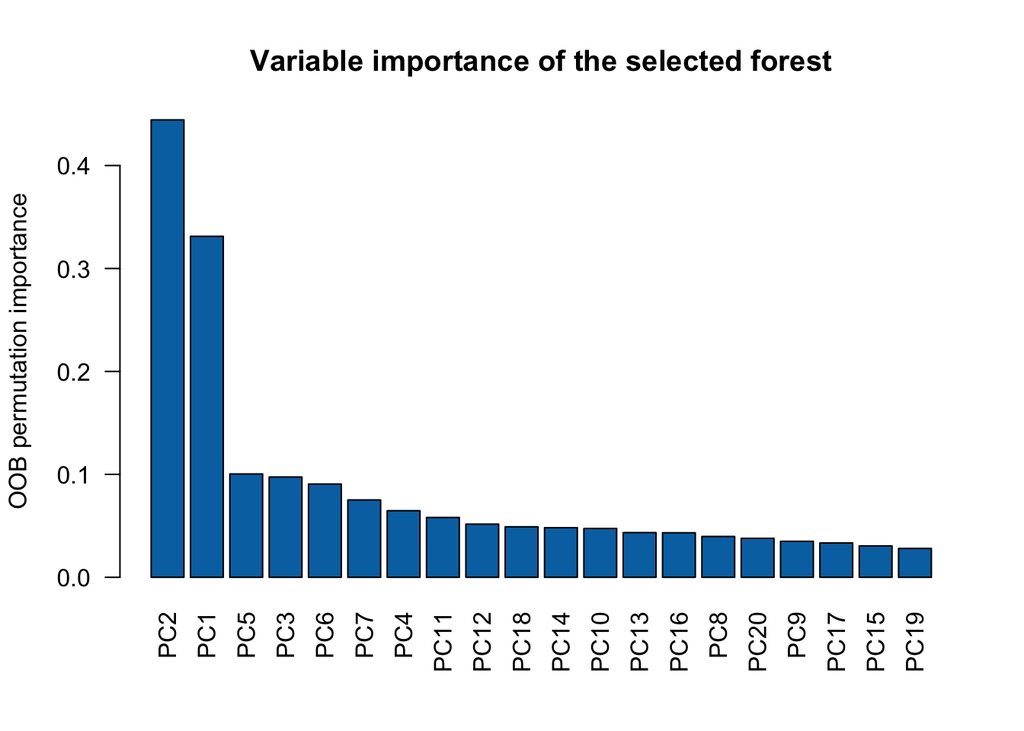

```r
barplot(sort(imp, decreasing = TRUE), las = 2, col = "#0072B2",
        ylab = "OOB permutation importance", main = "Variable importance of the selected forest")
```

The grid had mtry values 2, 4, 6, 10, 14, 20 and node sizes 1, 3, 5, 10, 20, which gives 30 settings. The OOB misclassification rate of each setting is in the table above. It ranges from 0.0214 to 0.0428. The lowest value is at mtry = 2 and node size 1 (0.0214), so these are the selected values. The table also shows that the OOB error tends to be lower for small mtry and small node size and higher for large node size, but the differences are small. With 327 training observations, one misclassified observation changes the OOB error by 0.003, so many neighboring settings differ by only one to three observations, and I would not claim that the selected setting is clearly better than the others. When I refit the forest with the selected values to compute variable importance, its OOB error was 0.0336, higher than the 0.0214 in the grid. This difference comes from the randomness in the forest (random bootstrap samples and random predictor choices), and it shows that the minimum over 30 settings is optimistic.

3. Apply the selected model to the test data and report the misclassification rate and confusion matrix. Use the test labels only for this final assessment.

```r
pr_test <- predict(fit_best, Zte)
pred_test <- factor(levels(ytr)[max.col(pr_test$ProbPrediction, ties.method = "first")],
                    levels = levels(ytr))
table(Observed = yte, Predicted = pred_test)
```

```
        Predicted
Observed   1   6   7
       1 102   0   2
       6   1 105   0
       7   1   1 105
```

```r
mean(pred_test != yte)
```

```
[1] 0.01577287
```

The test set has 317 observations: 104 of digit 1, 106 of digit 6, and 107 of digit 7. The selected forest (mtry = 2, node size 1) misclassifies 5 of them, a test misclassification rate of 0.0158, or about 1.6 percent. The confusion matrix has the observed digit in the rows and the predicted digit in the columns. Digit 1 is correct 102 times out of 104 (both errors predicted as a 7). Digit 6 is correct 105 times out of 106 (one error predicted as a 1). Digit 7 is correct 105 times out of 107 (one error predicted as a 1 and one as a 6). The test error is lower than the OOB error estimates (0.0214 in the grid and 0.0336 for the refitted forest). The binomial standard error of the test error is about 0.007, so these estimates are consistent with each other, and the OOB error from the grid is optimistic because it is the minimum over 30 settings. The test labels were used only for this final assessment.

## Question 3: Planning a random-forest analysis skill

In earlier homework, some students wrote long skill files with detailed instructions, while others wrote short skills emphasizing their specific requirements or references. These approaches may perform differently depending on the AI and the task. A capable AI may already know standard ways to perform an analysis, so some instructions may be redundant, add little value, or sometimes make the analysis worse. It may be more useful to specify your personal choices for the analysis. An AI with more limited knowledge may benefit from detailed instructions that remind it of the steps to perform.

1. Write one paragraph describing how you would write a skill that directs an AI to perform a random-forest analysis and produce a report for a future dataset. Discuss how you would balance standard analysis instructions with your personal preferences, considering the AI’s capabilities.

I would keep the skill short and concise. This way the AI will be able to understand the important requirements and still implement my personal preferences. I want the skill to tell the AI what basic rules to follow in order to avoid things like data leakage. I would then want to include my personal preferences for the analysis, emphasizing clarity as well as short rules. I would then run the skill and make any adjustments that are necessary based on the results.

2. Provide **10 instructions** you would consider including in the skill, **ordered from the most basic instructions to the more personal preferences**. Your list may cover computation, tuning, tables, figures, interpretation, presentation, or other aspects of a random-forest report.

You only need to discuss how the skill should be written. You are not required to write a complete skill file or test it.

1. Check that the data are suitable before fitting: variable types, missing values, sample size, class balance, and identifier or leakage variables. State what was found.
2. Set and report a random seed, and reserve a test set before any modeling or tuning. Do not touch the test set until the final assessment.
3. Fit any preprocessing, such as scaling, imputation, or PCA, on the training data only, and apply the same transformation unchanged to the test data.
4. Use enough trees for the error to stabilize (at least 250), and use the out-of-bag error to tune the forest instead of building a separate validation step.
5. Tune the number of candidate predictors and the node size on a small grid that includes the defaults. Choose the setting with the lowest OOB error, and when several settings are within a few observations of it, prefer the simpler or faster one.
6. Report the OOB error of every setting in the grid, not just the winner, together with the selected values and the OOB error of the final refit.
7. Use the test set once, at the end, to report the test error (misclassification rate or mean squared error) with a standard error, and a confusion matrix for classification.
8. Report permutation variable importance from the out-of-bag data as a ranked table or bar plot, and note that importance is not causal and can be spread across correlated predictors.
9. Interpret the results in plain language, say when differences between settings are within noise, and point out that the minimum of the tuning grid is an optimistic estimate of the error.
10. Keep the report short, with one table, one figure, and brief prose; use large, readable text and colorblind-safe colors; leave the code out of the report but keep it saved; and list any choices the skill did not specify.